# Brazilian Flora 2020 - Exploratory Analysis

Lucas Moraes

23/01/2019

Essa é uma pequena análise explorando os dados de espécies nativas da flora brasileira. Esta é parte de uma série de três análises integrando dados do projeto Flora 2020 do Jardim Botânico do Rio de Janeiro, Global Biodiversity Information Facility (GBIF) e a Lista Vermelha da IUCN. O objetivo dessa série é analisar algumas informações jogadas em minha nuvem de “coisas para explorar da flora” que não tive tempo enquanto ainda trabalhando na área, ao passo que treino/refino algumas técnicas de análise de dados e estatística em geral e ainda guardo alguns códigos, paradigmas e pipelines úteis para outras instâncias.

Esta primeira parte visa extrair, manipular e limpar dados da flora 2020 e constuir algumas visualizações gerais sobre os dados. Uma segunda parte, mais voltada para a análise estatística dos dados e desenho experimental já está em andamento e uma terceira já está planejada para ser conduzida em seguida. Todas estas análises estão sob constante revisão, sofrendo constantes alterações

Está análise está dividida em duas seções:

1. **Extração, limpeza e compilação de dados:** Aqui extraio os dados do projeto flora 2020 direto do IPT do JBRJ, observo a estrutura dos dados e formato/limpo ele da maneira que preciso para analisa-los da forma que pretendo. Essa parte da análise é relativamente extensa e técnica, sem análises de dados ou visualizações. Algumas das coisas dessa seção: especificamente aqui:
   - Extração e descompressão dos dados da flora 2020
   - Compilação de dados em um único data frame
   - Filtro de espécies
   - Limpeza de dados
   - Formatação de variáveis
   - Parsing
2. **Análise e visualização de dados:** Aqui, analiso o data frame unificado criado na etapa anterior, ploto algumas visuzalizações e mato a curiosidade sobre alguns aspectos dos dados. Algumas das coisas dessa seção:
   - Distribuição dos anos de descrição das espécies
   - Descrições anuais dos grandes grupos taxonômicos
   - Formas de vida e tipo de vegetação mais frequentes

Principais pacotes utilizados:

- [`tidyverse`](https://www.tidyverse.org/): Conjunto de pacotes com ferramentas de análise, transformação e visualização de dados.
- [`lubridate`](https://lubridate.tidyverse.org/): Manipulação de data e hora.
- [`patchwork`](https://github.com/thomasp85/patchwork): Combinar gráficos separados de maneira simples.
- [`ggrepel`](https://github.com/slowkow/ggrepel): Arranjo organizado de labels em plots.
- [`forcats`](https://forcats.tidyverse.org/): Manipulação mais intuitiva de variáveis categóricas.
- [`jsonlite`](https://cran.r-project.org/web/packages/jsonlite/vignettes/json-aaquickstart.html): Parsing de entradas *json*.
- [`PNWColors`](https://github.com/jakelawlor/PNWColors): Uma paleta de cores que gostei.
- `ggExtra`
- `plotly`
- `cowplot`

Ademais, escrevi algumas funções que auxiliaram na transformação desses dados, algumas explicitei no próprio documento, outras mais extensas não, mas todas podem ser encontradas no [repositório do projeto em meu github](https://github.com/moraessaur/flora2020_analysis/tree/master/scripts).

# 1 Extração, limpeza e compilação de dados

- Dados de descrição: anos em que as espécies foram descritas e os autores que as descreveram.
- Dados ecológicos e de distribuição: em que tipos de ambiente as espécies ocorrem e em quais estados brasileiros.
- Dados vernaculares: nomes populares dados às espécies.

Essas informações encontram-se armazenadas em uma série de arquivos organizados como tabelas interrelacionais. Se encontram no formato [Darwin Core (DwC-A)](https://www.ncbi.nlm.nih.gov/pmc/articles/PMC3253084/pdf/pone.0029715.pdf), um padrão de formatação de dados da biodiversidade. O projeto Flora 2020 armazena informações para todos níveis taxonômicos, mas nessa análise pretendo analisar apenas o nível de espécie.

## 1.1 Estrutura dos dados

Antes de mais nada, vou carregar todos pacotes e funções que irei utilizar daqui em diante:

```r
# primeiro as funções já citadas:
library(tidyverse)
library(lubridate)
library(patchwork)
library(ggrepel)
library(forcats)
library(PNWColors)
library(jsonlite)
```

```r
library(ggExtra)
library(plotly)
library(cowplot)
# depois as funções que eu escrevi
source("scripts/flora_2020_analysis_functions.R")
# paleta de cores utilizada
pal=pnw_palette("Bay",5, type = "discrete")
```

As informações que busco estão nos arquivos .txt do DwC-A:

```r
grep(".txt",list.files("data/"),value=TRUE)
```

```
## [1] "distribution.txt"         "reference.txt"
## [3] "resourcerelationship.txt" "speciesprofile.txt"
## [5] "taxon.txt"                "typesandspecimen.txt"
## [7] "vernacularname.txt"
```

Quero compilar informações de 5 arquivos:

1. **taxon.txt:** contém as informações mais básicas que preciso para começar a análise, como as informações taxonômicas das entradas e autores de descrição. Lembrando que os dados desse arquivo se aplicam a **todos** níveis taxonômicos contemplados no projeto (**e.g.** reino e gênero).
2. **reference.txt**: contém informações relativas à descrição dos taxa (**e.g.** ano e autor).

3.**distribution.txt:** informa se os taxa são endemicos ou não e em que domínios fitogeográficos ou estados brasileiros eles ocorrem.

4.**specieprofile.txt:** contém informações acerca da forma de vida, habitat e tipo de vegetação de ocorrência dos taxa.

5.**vernacular.txt:** contém os nomes populares das espécies.

Não vou usar os demais arquivos, `typesandspecimen.txt` e `resourcerelationship.txt`, pois eles se referem a dados não utilizados em minhas análises. Sempre vale lembrar também que a informação que busco nessa análise muito provavelmente não existe para todas espécies da amostra.

Vou então ler todos esses arquivos:

```r
taxon <- read_delim(file="data/taxon.txt", delim = "\t")
distribution <- read_delim(file="data/distribution.txt", delim = "\t")
references <- read_delim("data/reference.txt", delim = "\t")
vernacular <- read_delim("data/vernacularname.txt", delim = "\t")
profile <- read_delim("data/speciesprofile.txt", delim = "\t")
```

O que quero fazer em seguida é compilar *apenas* as informações que preciso de cada um desses arquivos, armazenando tudo em um único data frame que vou chamar de `df_master`.

## 1.2 Filtrando espécies nativas:

Para esta análise, quero trabalhar apenas com espécies nativas e sem problemas nomenclaturais de qualquer tipo (não são sinônimos, espécies naturalizadas ou invasivas, nem representam nomes em desuso). Para fazer isso vou começar filtrando as colunas `taxonomicStatus`, `nomenclaturalStatus` e `taxonRank` da tabela `taxon`.

A coluna `taxonomicStatus` indica se um registro se refere a um nome aceito ou sinônimo:

```r
unique(taxon$taxonomicStatus)
```

```
## [1] "NOME_ACEITO" "SINONIMO"    NA
```

Já a coluna `nomenclaturalStatus` indica se o nome em questão é correto ou se existe algum tipo de problema associado a ele:

```r
unique(taxon$nomenclaturalStatus)
```

```
##  [1] "NOME_CORRETO"                    NA
##  [3] "NOME_LEGITIMO_MAS_INCORRETO"     "NOME_CORRETO_VIA_CONSERVACAO"
##  [5] "VARIANTE_ORTOGRAFICA"            "NOME_ILEGITIMO"
##  [7] "NOME_NAO_EFETIVAMENTE_PUBLICADO" "NOME_NAO_VALIDAMENTE_PUBLICADO"
##  [9] "NOME_MAL_APLICADO"               "NOME_REJEITADO"
## [11] "NOME_APLICACAO_INCERTA"
```

Um taxon pode não ter tido seu nome publicado ainda ou pode ter sido catalogado de forma incorreta por algum motivo. Vou seguir mantendo apenas espécies que tem nomes corretos sem qualquer tipo de problema.

Finalmente, a tabela `taxonRank` indica o nível taxonomico do registro:

```r
unique(taxon$taxonRank)
```

```
##  [1] "ORDEM"       "FAMILIA"     "GENERO"      "ESPECIE"     "VARIEDADE"
##  [6] "SUB_ESPECIE" "CLASSE"      "TRIBO"       "SUB_FAMILIA" "DIVISAO"
## [11] "FORMA"
```

Faço então todos filtros que preciso e mantenho na tabela `taxon` apenas as espécies que seguem meus critérios:

```r
taxon <- taxon %>% filter(taxonomicStatus == "NOME_ACEITO", # apenas nomes aceitos
                              nomenclaturalStatus == "NOME_CORRETO", # apenas nomes corretos
                              taxonRank == "ESPECIE") # apenas nomes que se referem a espécies
```

Ainda assim, ainda não filtrei as espécies nativas da amostra, dado que essa informação não está contida na tabela `taxon`, pois está na arquivo `distribution`, especificamente na coluna `establishmentMeans`. Para filtrar isso posso usar os id´s da tabela taxon, que agora contém apenas as espécies com nome correto:

```r
# filtro entradas nativas na tabela distribution
distribution <- distribution %>% filter(establishmentMeans == "NATIVA")

# extraio as id´s que se referem à espécies nativas
ids_native <- unique(distribution$id)

# filtro tabela taxon novamente, mantendo apenas espécies nativas
taxon <- taxon %>% filter(id %in% ids_native)
```

A tabela `taxon` agora está do jeito que quero, apenas com espécies nativas e com nomes livres de problemas. Essa tabela vai formar a base do `df_master`, então, a partir dela vou selecionar apenas minhas variáveis de interesse e incrementar aos poucos com novas informações das demais tabelas que ainda resta analisar:

```r
# criando df_master a partir das variáveis de interesse da colunas taxon

df_master <- taxon %>%
              select(id, # id das especies
                     scientificName, # nome científico
                     higherClassification, # backbone taxonomico
                     family) # familia
```

Vale dar uma olhada geral na estrutura da tabela:

```r
glimpse(df_master)
```

```
## Rows: 38,079
## Columns: 4
## $ id                   <dbl> 264, 280, 285, 301, 315, 319, 342, 343, 439, 440…
## $ scientificName       <chr> "Adiscanthus fusciflorus Ducke", "Andreadoxa fla…
## $ higherClassification <chr> "Flora;Angiospermas;Rutaceae A.Juss.;Adiscanthus…
## $ family               <chr> "Rutaceae", "Rutaceae", "Rutaceae", "Rutaceae", …
```

Parece razoável, embora ainda vá mexer nos tipos das variáveis mais adiante. A tabela contém a informação de 38079 espécies nativas da flora brasileira, mas ainda falta coisa para ser compilada.

## 1.3 Compilando os dados restantes

Agora vou extrair as demais informações seguindo uma lógica utilizada na tabela `taxon`, mas usando a função `match`. Especificamente, quero puxar os dados abaixo das espécies:

- Ano de descrição
- Autor da descrição
- Domínios fitogeográficos de ocorrência
- Estados da Federação (ou do que resta dela) de ocorrência
- Formas de vida
- Tipos de vegetação de ocorrência
- Nomes populares

### 1.3.1 Autores e anos de descrição das espécies

A tabela `references` contém o ano de descrição e autoria das mesmas para as espécies, respectivamente nas colunas `date` e `creator`. Ao incluir essas informações no `df_master`, vou criar nomes mais intuitivos para as colunas:

```r
ids_master <- df_master[["id"]] # pego as ids das espécies contidas no df_master

# nova coluna criada com os anos de descrição das espécies

df_master[["desc_year"]] <- references$date[match(ids_master,references$id)]

# mesma coisa com os autores

df_master[['descriptor']] <- references$creator[match(ids_master,references$id)]
```

Antes de seguir em frente, já vou limpar a coluna de datas que apresenta alguns problemas:

```r
unique(df_master$desc_year)[250:300]
```

```
##  [1] "1994/1995"
##  [2] "107"
##  [3] "1809"
##  [4] "2018"
##  [5] "147"
##  [6] "1868-70"
##  [7] "393"
##  [8] "187"
##  [9] "2019"
## [10] "1831-1834"
## [11] "1785"
## [12] "1796"
## [13] "1814"
## [14] "1794"
## [15] "189"
```

[output cut: 36 more lines]

Vou ser um pouco conservador na minha abordagem e eliminar tudo que não tem mais de quatro caracteres (já que a coluna está formatada como string):

```r
# função para limpar as datas:
  # se data for NA, mantem como NA
  # se data tiver quatro caracteres, mantem data
  # se não, retorna NA
clean_dates <- function(x){
  if(is.na(x)){return(NA)
    break
  }
  if (nchar(x) == 4){return(x)}
  else{return(NA)}}

# vou aplicar a função para a coluna toda e converter o tipo para numerico
  # tipo numerico vai converter para NA o que tiver letra dentre os quatro char

df_master[['desc_year']] <- df_master[['desc_year']] %>% # coluna
                              map(clean_dates) %>%  # aplicar função
                              as.numeric() # deixar como tipo numerico
```

Vou dar uma olhada nas estatísticas sumarizadas da coluna:

```r
summary(df_master[['desc_year']])
```

```
##    Min. 1st Qu.  Median    Mean 3rd Qu.    Max.    NA's
##    1071    1893    1976    1948    2003    3013   14661
```

O mínimo e o máximo ainda estão bem esquisitos, vou manter apenas datas que se encontram em um intervalo de tempo rezoável: entre 1700 (pouco antes do estabelecimento do sistema lineniano) e 2020. O resto vou converter para NA.

```r
year_fix <- function(x){
  if (is.na(x)){return(NA)} # se o ano é NA, retorna NA
  if (x<1700 || x>2020){return(NA)}else{return(x)} # valores fora do intervalo retornam NA
}

# recriando coluna aplicando a função à coluna existente

df_master <- df_master %>% mutate(desc_year = modify(df_master[['desc_year']],year_fix))
```

Os valores agora parecem fazer mais sentido:

```r
sort(unique(df_master[['desc_year']]))
```

```
##   [1] 1752 1753 1755 1756 1759 1760 1762 1763 1764 1765 1766 1767 1768 1771 1772
##  [16] 1773 1775 1781 1782 1783 1784 1785 1786 1788 1789 1791 1792 1793 1794 1796
##  [31] 1797 1798 1799 1800 1801 1802 1803 1804 1805 1806 1807 1808 1809 1810 1811
##  [46] 1812 1813 1814 1815 1816 1817 1818 1819 1820 1821 1822 1823 1824 1825 1826
##  [61] 1827 1828 1829 1830 1831 1832 1833 1834 1835 1836 1837 1838 1839 1840 1841
##  [76] 1842 1843 1844 1845 1846 1847 1848 1849 1850 1851 1852 1853 1854 1855 1856
##  [91] 1857 1858 1859 1860 1861 1862 1863 1864 1865 1866 1867 1868 1869 1870 1871
## [106] 1872 1873 1874 1875 1876 1877 1878 1879 1880 1881 1882 1883 1884 1885 1886
## [121] 1887 1888 1889 1890 1891 1892 1893 1894 1895 1896 1897 1898 1899 1900 1901
## [136] 1902 1903 1904 1905 1906 1907 1908 1909 1910 1911 1912 1913 1914 1915 1916
## [151] 1917 1918 1919 1920 1921 1922 1923 1924 1925 1926 1927 1928 1929 1930 1931
## [166] 1932 1933 1934 1935 1936 1937 1938 1939 1940 1941 1942 1943 1944 1945 1946
## [181] 1947 1948 1949 1950 1951 1952 1953 1954 1955 1956 1957 1958 1959 1960 1961
## [196] 1962 1963 1964 1965 1966 1967 1968 1969 1970 1971 1972 1973 1974 1975 1976
## [211] 1977 1978 1979 1980 1981 1982 1983 1984 1985 1986 1987 1988 1989 1990 1991
## [226] 1992 1993 1994 1995 1996 1997 1998 1999 2000 2001 2002 2003 2004 2005 2006
## [241] 2007 2008 2009 2010 2011 2012 2013 2014 2015 2016 2017 2018 2019 2020
```

### 1.3.2 Estados da federação, endemismo, domínio fitogeográfico, informações ecológicas e vernaculares

Agora vou adicionar as informações da tabela `distribution`. A coluna `location_id` contém a informação acerca dos estados no Brasil onde as espécies ocorrem. Cada id é repetido por número estado de ocorrência:

```r
distribution %>% filter(id == 264)
```

| id | locationID | countryCode | establishmentMeans | occurrenceRemarks |
| --- | --- | --- | --- | --- |
| 264 | BR-PA | BR | NATIVA | {"endemism":"Não endemica","phytogeographicDomain":["Amazônia"]} |
| 264 | BR-AM | BR | NATIVA | {"endemism":"Não endemica","phytogeographicDomain":["Amazônia"]} |
| 264 | BR-AC | BR | NATIVA | {"endemism":"Não endemica","phytogeographicDomain":["Amazônia"]} |

Essa espécie ocorre no Pará, Amazonas e Acre. Vou inserir essas informações para as espécies no `df_master` de modo elas fiquem agrupadas em uma única string, usando um separador:

```r
# nessa função, indico qual o separador que vou usar depois de especificar uma id (x), coluna e tabela.

collapse_column <- function(x,column,df,split_character=";"){
  df_temp <- df %>% filter(id == x)
  if (length(rownames(df_temp)) == 0){return(NA)} else {
    output <- paste(df_temp[[column]],collapse = split_character)
    return(output)
  }
}


# crio uma nova coluna 'states' com as informações de estado de ocorrência

df_master[['states']] <- map(ids_master,collapse_column,column="locationID",df=distribution) %>%
                        gsub("BR-","",.) # removendo o prefixo para ficar mais limpo
```

E a coluna fica com uma cara assim:

```r
df_master['states'] %>% slice(1:10) #first ten entries of the column
```

| states |
| --- |
| PA;AM;AC |
| BA |
| RJ;ES;BA |
| AC;MT |
| MA;PA |
| AM |
| MG;SE;PI;PE;CE;BA |
| SP;MG;SC;RS;PR;MS |
| AM;AC |
| RJ;ES;PE;BA |

Agora vou extrair as informações de domínios de ocorrência e endemismo, ambas contidas nas colunas `occurrenceRemarks`, ainda da tabela `distribution`. Essas informações estão armazenadas no formato *json*:

```r
distribution$occurrenceRemarks[5000]
```

```
## [1] "{\"endemism\":\"Não endemica\",\"phytogeographicDomain\":[\"Amazônia\"]}"
```

Vou extrair nesse formato mesmo e fazer o parse mais adiante:

```r
df_master['distribution']<-distribution$occurrenceRemarks[match(ids_master,distribution$id)]
```

As informações ecológicas estão armazenadas de maneira semelhante, na tabela `profile`, em uma coluna de nome não muito intuitivo: `lifeForm`. Incluir esses dados direto em uma coluna do `df_master` e fazer o parsing depois.

```r
df_master['profile'] <- profile$lifeForm[match(ids_master,profile$id)]
```

Já os nomes vernaculares das espécies encontram-se na coluna `vernacularName` da tabela `vernacular`, armazenados da mesma forma que os estados de ocorrência, então vou usar a função que utilizei no caso dos estados, gerando uma nova coluna no `df_master` chamada `vernacular_name`:

```r
df_master['vernacular_name'] <-
  map(ids_master,collapse_column,
  column="vernacularName",df=vernacular) %>%
  unlist()
```

### 1.3.3 Parsing

A maior parte dos dados que preciso já estão no `df_master`, mas ainda preciso fazer o parsing daquelas colunas no formato json. Vou chamar uma função que fiz para lidar com isso, o que essa função faz é quebrar em colunas a informação contida nos json, por exemplo, isso aqui:

```r
# vector of rows from the distribution column, in json format
df_master$distribution[1507:1508]
```

```
## [1] "{\"endemism\":\"Endemica\",\"phytogeographicDomain\":[\"Mata Atlântica\"]}"
## [2] "{\"endemism\":\"Endemica\",\"phytogeographicDomain\":[\"Mata Atlântica\"]}"
```

Toma esse formato, onde as chaves se tornam colunas com a informação pertinente:

```r
json_parser(df_master$distribution[1507:1508])
```

| endemism | phytogeographicDomain |
| --- | --- |
| Endemica | Mata Atlântica |
| Endemica | Mata Atlântica |

Então uso a função nas colunas inteiras que contém informação como JSON e este problema está resolvido:

```r
# parsing da coluna distribution
  # cada chave vai ser uma coluna nova
df_master <- json_parser(df_master$distribution) %>%
              bind_cols(df_master) %>% # incluo a informação no df_master
              select(-distribution) # remove a coluna com os JSON, agora obsoleta

# mesma coisa com a coluna profile
df_master <- json_parser(df_master$profile) %>%
              bind_cols(df_master) %>%
              select(-profile,-habitat) # alem de remover a coluna obsoleta, tirei a coluna da chave habitat, que não vai ser utilizada na análise
```

```r
head(df_master)
```

| lifeForm | vegetationType | endemism | phytogeographicDomain | id | scientificName | higherClassification | family | desc_year | descriptor | states | vernacular_name |
| --- | --- | --- | --- | --- | --- | --- | --- | --- | --- | --- | --- |
| Árvore | Campinarana;Floresta Ombrófila (= Floresta Pluvial) | Não endemica | Amazônia | 264 | Adiscanthus fusciflorus Ducke | Flora;Angiospermas;Rutaceae A.Juss.;Adiscanthus Ducke;Adiscanthus fusciflorus Ducke | Rutaceae | 1922 | NA | PA;AM;AC | NA |
| Árvore | Floresta Ombrófila (= Floresta Pluvial) | Endemica | Mata Atlântica | 280 | Andreadoxa flava Kallunki | Flora;Angiospermas;Rutaceae A.Juss.;Andreadoxa Kallunki;Andreadoxa flava Kallunki | Rutaceae | 1998 | NA | BA | NA |
| Árvore | Floresta Ombrófila (= Floresta Pluvial) | Endemica | Mata Atlântica | 285 | Angostura bracteata (Nees & Mart.) Kallunki | Flora;Angiospermas;Rutaceae A.Juss.;Angostura Roem. & Schult.;Angostura bracteata (Nees & Mart.) Kallunki | Rutaceae | 1998 | NA | RJ;ES;BA | gramirim-café |
| Árvore | Floresta de Terra Firme;Floresta Ombrófila (= Floresta Pluvial) | Não endemica | Amazônia | 301 | Angostura longiflora (K.Krause) Kallunki | Flora;Angiospermas;Rutaceae A.Juss.;Angostura Roem. & Schult.;Angostura longiflora (K.Krause) Kallunki | Rutaceae | 1998 | NA | AC;MT | matapira;mata rabujo;pirarara branca |
| Árvore | Floresta de Terra Firme;Floresta Ombrófila (= Floresta Pluvial) | Endemica | Amazônia | 315 | Angostura quinquefolia Kallunki | Flora;Angiospermas;Rutaceae A.Juss.;Angostura Roem. & Schult.;Angostura quinquefolia Kallunki | Rutaceae | 1998 | NA | MA;PA | NA |
| Árvore | Floresta de Terra Firme;Floresta Ombrófila (= Floresta Pluvial) | Não endemica | Amazônia | 319 | Angostura simplex Kallunki | Flora;Angiospermas;Rutaceae A.Juss.;Angostura Roem. & Schult.;Angostura simplex Kallunki | Rutaceae | 1998 | NA | AM | NA |

```r
head(df_master[["higherClassification"]])
```

```
## [1] "Flora;Angiospermas;Rutaceae A.Juss.;Adiscanthus Ducke;Adiscanthus fusciflorus Ducke"
## [2] "Flora;Angiospermas;Rutaceae A.Juss.;Andreadoxa Kallunki;Andreadoxa flava Kallunki"
## [3] "Flora;Angiospermas;Rutaceae A.Juss.;Angostura Roem. & Schult.;Angostura bracteata (Nees & Mart.) Kallunki"
## [4] "Flora;Angiospermas;Rutaceae A.Juss.;Angostura Roem. & Schult.;Angostura longiflora (K.Krause) Kallunki"
## [5] "Flora;Angiospermas;Rutaceae A.Juss.;Angostura Roem. & Schult.;Angostura quinquefolia Kallunki"
## [6] "Flora;Angiospermas;Rutaceae A.Juss.;Angostura Roem. & Schult.;Angostura simplex Kallunki"
```

### 1.3.4 Ajustes finais:

A maior parte dos dados já está pronta, mas a tabela ainda precisa de uns ajustes finais. Por exemplo, seria melhor remover acentos de algumas colunas do `df_master`, dado que eles podem ser problemáticos para algumas visualizações:

```r
df_master <- df_master %>%
        # vou selecionar apenas as colunas que quero formatar
        mutate_at(c("lifeForm","endemism","vernacular_name","major_group"),
                  iconv,from="UTF-8",to="ASCII//TRANSLIT") # iconv remove os acentos dessas colunas
```

Também vou reordenar e renomear as colunas de maneira mais intuitiva:

```r
df_master <- df_master %>%
              # reorder columns
              select(id,major_group,
                     family,scientificName,
                     desc_year,descriptor,
                     lifeForm,vegetationType,
                     endemism,phytogeographicDomain,
                     states,vernacular_name) %>%
              # rename some columns
              rename(scientific_name=scientificName,
                                   phytogeographic_domains=phytogeographicDomain,
                                   life_form=lifeForm,
                                   vegetation_type=vegetationType)
```

Agora vale uma reolhada na estrutura do data frame para checar os tipos das variáveis:

```r
glimpse(df_master)
```

```
## Rows: 38,079
## Columns: 12
## $ id                      <dbl> 264, 280, 285, 301, 315, 319, 342, 343, 439, …
## $ major_group             <chr> "Angiospermas", "Angiospermas", "Angiospermas…
## $ family                  <chr> "Rutaceae", "Rutaceae", "Rutaceae", "Rutaceae…
## $ scientific_name         <chr> "Adiscanthus fusciflorus Ducke", "Andreadoxa …
## $ desc_year               <dbl> 1922, 1998, 1998, 1998, 1998, 1998, 1998, 189…
## $ descriptor              <chr> NA, NA, NA, NA, NA, NA, NA, NA, NA, NA, NA, "…
## $ life_form               <chr> "Arvore", "Arvore", "Arvore", "Arvore", "Arvo…
## $ vegetation_type         <chr> "Campinarana;Floresta Ombrófila (= Floresta P…
## $ endemism                <chr> "Nao endemica", "Endemica", "Endemica", "Nao …
## $ phytogeographic_domains <chr> "Amazônia", "Mata Atlântica", "Mata Atlântica…
## $ states                  <chr> "PA;AM;AC", "BA", "RJ;ES;BA", "AC;MT", "MA;PA…
## $ vernacular_name         <chr> NA, NA, "gramirim-cafe", "matapira;mata rabuj…
```

A maior parte das colunas está formatada como string, embora a maioria seja constituída de variáveis categóricas, vou converter todas que não contém separadores e que não são números para fatores:

```r
glimpse(
  df_master <- df_master %>% mutate_at(c("life_form",
                          "endemism",
                          "scientific_name",
                          "family"), as.factor)
  )
```

```
## Rows: 38,079
## Columns: 12
## $ id                      <dbl> 264, 280, 285, 301, 315, 319, 342, 343, 439, …
## $ major_group             <chr> "Angiospermas", "Angiospermas", "Angiospermas…
## $ family                  <fct> Rutaceae, Rutaceae, Rutaceae, Rutaceae, Rutac…
## $ scientific_name         <fct> Adiscanthus fusciflorus Ducke, Andreadoxa fla…
## $ desc_year               <dbl> 1922, 1998, 1998, 1998, 1998, 1998, 1998, 189…
## $ descriptor              <chr> NA, NA, NA, NA, NA, NA, NA, NA, NA, NA, NA, "…
## $ life_form               <fct> Arvore, Arvore, Arvore, Arvore, Arvore, Arvor…
## $ vegetation_type         <chr> "Campinarana;Floresta Ombrófila (= Floresta P…
## $ endemism                <fct> Nao endemica, Endemica, Endemica, Nao endemic…
## $ phytogeographic_domains <chr> "Amazônia", "Mata Atlântica", "Mata Atlântica…
## $ states                  <chr> "PA;AM;AC", "BA", "RJ;ES;BA", "AC;MT", "MA;PA…
## $ vernacular_name         <chr> NA, NA, "gramirim-cafe", "matapira;mata rabuj…
```

# 2 Análise e visualização dos dados

As variáveis que quero investigar podem ser agrupadas em 5 grupos e vou analisá-las de agregando informações de grupos distintos:

1. Temporais ano e autor da descrição das espécies
2. Geográficas estados e biomas de ocorrência
3. Ecológicas
4. Taxonômicas
5. Vernaculares

Com todas já compiladas no `df_master`, posso começar a mexer nos dados.

## 2.1 Descrições de espécies ao longo do tempo

Das 38079 espécies presentes no `df_master`, 23,415 possuem a informação referente ao ano de descrição. Isso corresponde a cerca de 61.4905854% da amostra. Ainda assim, um dado interessante de se visualizar:

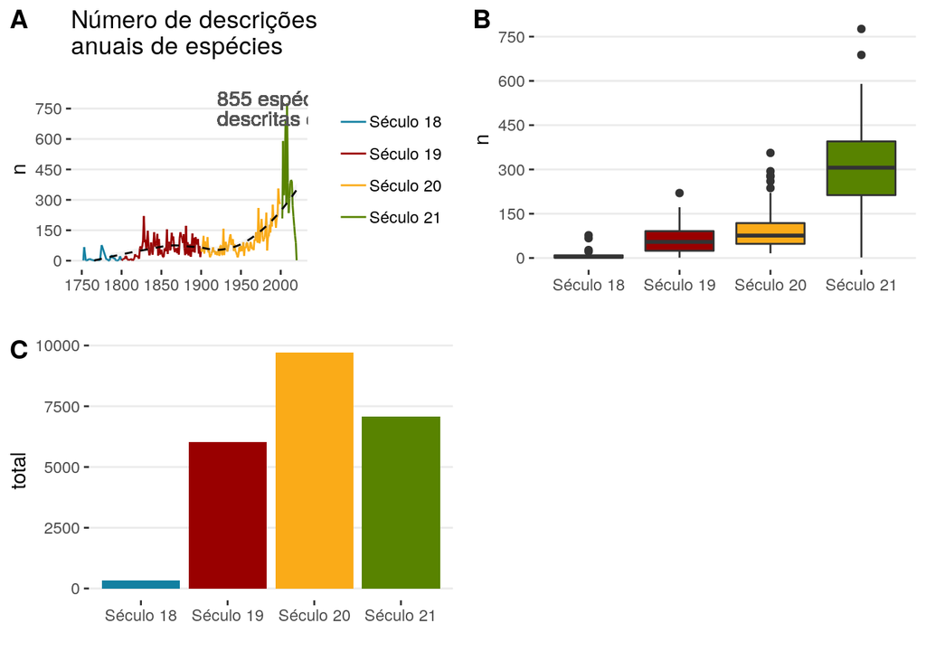

```r
# criando rapidamente tabela para o plot
  # contando ocorrência dos anos
  # incluindo uma coluna com o século de cada ano



p1 <- df_master %>%
  count(desc_year) %>%
  mutate(desc_century = case_when(desc_year < 1800 ~ "Século 18",
                                      desc_year >= 1800 & desc_year < 1900 ~ "Século 19",
                                      desc_year >= 1900 & desc_year < 2000 ~ "Século 20",
                                      desc_year > 2000 ~ "Século 21")) %>% na.omit() %>%
  ggplot(aes(x=desc_year,y=n,color=desc_century)) +
  geom_line(aes(group=1)) + coord_cartesian(ylim = c(0,900), xlim = c(1750,2020)) +
  theme_bw() +
  removeGridX() +
  theme(panel.border = element_blank()) + geom_smooth(aes(group=1),alpha=0.1, linetype = 'dashed', size = 0.5, color = 'black') +
geom_text(aes(x = 1920, y = 750, label = "855 espécies \ndescritas em 2001"),
             hjust = 0,
             vjust = 0.5,
             lineheight = 0.8,
             colour = "#555555",
             label.size = NA,
             size = 4) +
  geom_curve(aes(x = 2001, y = 855, xend = 1980, yend = 800), # acho que a seta não saiu no plot por causa do cowplot
                             colour = "#555555",
                             size=0.5,
                             curvature = 0.2,
                             arrow = arrow(length = unit(0.03, "npc"))) +
  scale_color_manual(values = c("#1380A1","#990000", "#FAAB18","#588300")) +
  scale_x_continuous(limits=c(1750,2020), breaks = seq(1750,2020,50)) + xlab('') +
  theme(legend.title = element_blank()) + ggtitle('Número de descrições \nanuais de espécies') +
  scale_y_continuous(limits = c(0,800),breaks=seq(0,800,150))
### Aqui vale uns labels no formato de tabela com os n de cada grupo

p2 <- df_master %>%
  count(desc_year) %>%
  mutate(desc_century = case_when(desc_year < 1800 ~ "Século 18",
                                      desc_year >= 1800 & desc_year < 1900 ~ "Século 19",
                                      desc_year >= 1900 & desc_year < 2000 ~ "Século 20",
                                      desc_year > 2000 ~ "Século 21")) %>% na.omit() %>%
  ggplot(aes(x=desc_century,y=n,fill=desc_century)) + geom_boxplot() +
  scale_fill_manual(values = c("#1380A1","#990000", "#FAAB18","#588300")) +
  theme_bw() +
  removeGridX() +
  theme(panel.border = element_blank(), legend.position = "none") + xlab("") +
  scale_y_continuous(limits = c(0,800),breaks=seq(0,800,150))

p3 <- df_master %>%
  count(desc_year) %>%
  mutate(desc_century = case_when(desc_year < 1800 ~ "Século 18",
                                  desc_year >= 1800 & desc_year < 1900 ~ "Século 19",
                                  desc_year >= 1900 & desc_year < 2000 ~ "Século 20",
                                  desc_year > 2000 ~ "Século 21")) %>% na.omit() %>%
  group_by(desc_century) %>% summarise(total=sum(n)) %>%
  ggplot(aes(x=desc_century,y=total, fill = desc_century)) + geom_bar(stat='identity') +
  scale_fill_manual(values = c("#1380A1","#990000", "#FAAB18","#588300")) +
  theme_bw() +
  removeGridX() +
  theme(panel.border = element_blank(), legend.position = "none") + xlab("")





(grid_p <- plot_grid(p1,p2,p3, nrow=2,ncol = 2,labels = c('A', 'B','C')))
```

```r
head(df_master %>%
       filter(desc_year == 2001) %>%
       {table(.$descriptor)} %>%
       as.data.frame() %>%
       arrange(desc(Freq))) %>%
  rename(author=Var1,species_descriptions=Freq)
```

|  | author | species_descriptions |
| --- | --- | --- |
| 1 | Menezes, M. & Dias, I.C.A. (Orgs.) | 504 |
| 2 | Esteves, G.L. | 33 |
| 3 | Torgan, L.C., Barreda, K.A. & Fortes, D.F. | 30 |
| 4 | Berg, C.C. | 24 |
| 5 | Dias, I.C.A. et al. | 23 |
| 6 | Cristóbal, C.L. | 20 |

O fato de o termo *Orgs.* aparecer no autor com maior número de descrições de 2001 indica ser uma obra. Ainda, o número de espécies descritas associadas com esse nome é muito maior que a média dos demais autores, o que faz sentido, dado que a obra deve compilar descrições de uma série de autores. Uma busca rápida me mostrou que um livro entitulado [“Biodiversidade de algas de ambientes continentais do Estado do Rio de Janeiro”](https://www.researchgate.net/publication/44430175_Biodiversidade_de_algas_de_ambientes_continentais_do_Estado_do_Rio_de_Janeiro_organizadoras_Mariangela_Menezes_Izabel_Cristina_Alves_Dias), com as referidas autoras. Partindo do título, podemos pressupor que uma grande quantidade de algas foram descritas nesse ano. Normalmente espera-se que o número absoluto de angiospermas descritas por ano seja maior que os demais grandes grupos, isso fica mais evidente quando os dados são agrupados por século:

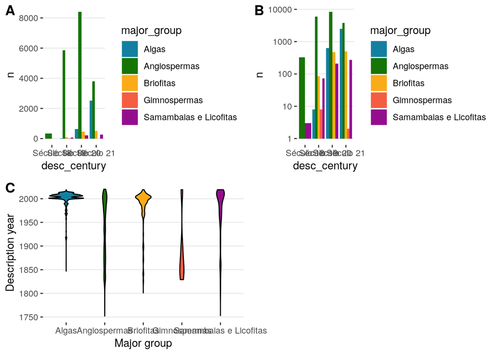

```r
p1 <- df_master %>%
  mutate(desc_century = case_when(desc_year < 1800 ~ "Século 18",
                                      desc_year >= 1800 & desc_year < 1900 ~ "Século 19",
                                      desc_year >= 1900 & desc_year < 2000 ~ "Século 20",
                                      desc_year > 2000 ~ "Século 21")) %>% group_by(desc_century) %>%
  count(major_group) %>% na.omit() %>%
 ggplot(aes(x=desc_century,y=n, fill = major_group)) + geom_bar(stat='identity', position = 'dodge') +
 scale_fill_manual(values = c("#1380A1",'#177506', "#FAAB18","#f55d42",'#940d8f')) +
  theme_bw() +
  removeGridX() +
  theme(panel.border = element_blank())


p2 <- df_master %>%
  mutate(desc_century = case_when(desc_year < 1800 ~ "Século 18",
                                      desc_year >= 1800 & desc_year < 1900 ~ "Século 19",
                                      desc_year >= 1900 & desc_year < 2000 ~ "Século 20",
                                      desc_year > 2000 ~ "Século 21")) %>% group_by(desc_century) %>%
  count(major_group) %>% na.omit() %>%
 ggplot(aes(x=desc_century,y=n, fill = major_group)) + geom_bar(stat='identity', position = 'dodge') +
 scale_fill_manual(values = c("#1380A1",'#177506', "#FAAB18","#f55d42",'#940d8f')) +
  scale_y_log10() +
  theme_bw() +
  removeGridX() +
  theme(panel.border = element_blank())

p3 <- df_master %>% ggplot(aes(y=as.numeric(desc_year),x=major_group,fill=major_group)) +
  xlab("Major group") +
                ylab("Description year") +
                geom_violin(color = "black") +
                scale_fill_manual(values=c("#1380A1",'#177506', "#FAAB18","#f55d42",'#940d8f')) +
                theme_bw() +
                theme(plot.title = element_text(hjust=0.5),
                      legend.position = "none") +
                removeGridX() +
              theme(panel.border = element_blank())


(grid_p <- plot_grid(p1,p2,p3, nrow=2,ncol = 2,labels = c('A', 'B','C')))
```

Ambos gráficos contém a mesma informação, mas dado que a quantidade de angiospermas descritas é muito grande e a quantidade de gimnospermas descritas muito pequenas, colocar em escala logarítmica permite-nos visualizar este último grupo. Gimnospermas aparecem descritas apenas no século 19 e 21, sendo a maioria no primeiro. Esse fato é reforçado no gráfico de violino, que indica essa maior densidade de descrições ao longo do século 19, seguido por um hiato até o século 21, onde mais algumas poucas descrições são realizadas. Os gráficos também reforçam a importância do século 21 para a descrição de algas, que tiveram, além de uma maior quantidade em números absolutos, uma maior quantidade de espécies do total do grupo descritas recentemente. Embora, em média, uma maior quantidade de angiospermas sejam descritas anualmente, esse não foi o caso no ano de 2001, ano de lançamento do livro:

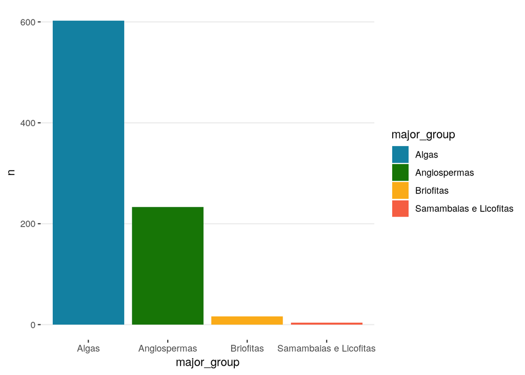

```r
df_master %>% filter(desc_year==2001) %>%
  count(major_group) %>% na.omit() %>%
 ggplot(aes(x=major_group,y=n, fill = major_group)) + geom_bar(stat='identity', position = 'dodge') +
 scale_fill_manual(values = c("#1380A1",'#177506', "#FAAB18","#f55d42",'#940d8f')) +
  theme_bw() +
  removeGridX() +
  theme(panel.border = element_blank())
```

```r
df_master$desc_year <- as.character(df_master$desc_year) # uhmmm isso nao deveria estar assim
df_temp <- df_stack_parse(df_master,column1 = "desc_year",column2 = "states",slice_value = 3,parse1 = FALSE)

df_temp[[1]] %>% rename(year=x,state=y,species_descriptions=value) %>% head()
```

| year | state | species_descriptions |
| --- | --- | --- |
| 1922 | PA | 35 |
| 1922 | AM | 27 |
| 1922 | AC | 13 |
| 1922 | BA | 5 |
| 1922 | RJ | 6 |
| 1922 | ES | 5 |

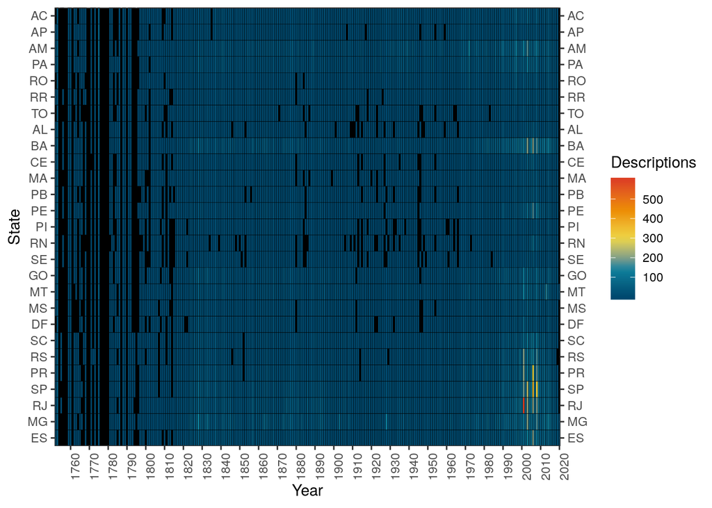

```r
x <- df_temp[[1]] # select the output I need from df_stack_bar
x <- x %>% filter(y != "NA") # remove NA values that were formatted as string
x$x <- as.numeric(x$x) # convert year column to numeric
x$y <- as.factor(x$y) # need to change the state column type to factor
                      # this will let me "disguise" these values as continuous
                      # which is how I will get thoses states on both sides
x <- x %>% filter(!is.na(y)) #remove true NA's
labs2 <- levels(x$y) # store the factor levels
labs2 <- c("ES", "MG", "RJ","SP",
                         "PR","RS","SC",
                         "DF","MS","MT","GO",
                         "SE","RN","PI","PE","PB","MA","CE",
                         "BA","AL","TO","RR","RO","PA","AM","AP","AC")




# plotting the heatmap:

x %>%
  mutate(y = fct_relevel(y,
                         "ES", "MG", "RJ","SP",
                         "PR","RS","SC",
                         "DF","MS","MT","GO",
                         "SE","RN","PI","PE","PB","MA","CE",
                         "BA","AL","TO","RR","RO","PA","AM","AP","AC")) %>%
  ggplot(aes(x, as.numeric(y), fill= value)) + #converting state names to numeric values
  geom_tile(colour = "black") +
  scale_fill_gradientn(colours = pal, name = "Descriptions", na.value = "black") +
  xlab("Year") + ylab("State") +
  theme_bw() +
  theme(axis.text.x = element_text(angle = 90),
        plot.title = element_text(hjust=0.5),
        panel.background = element_rect(fill="black", colour="black"),
        panel.grid.major = element_blank(),
        panel.grid.minor = element_blank()) +
  scale_x_continuous(breaks = seq(1750,2020,10),
                     expand = c(0,0)) + # remove panning
  scale_y_continuous(breaks = 1:length(labs2),
                     labels = labs2, # mask factor values as names
                     sec.axis = sec_axis(~., # secondary axis, only works with continuous values
                                         breaks = 1:length(labs2),
                                         labels = labs2),expand = c(0,0))
```

Este gráfico representa o número de espécies descritas por ano, por estado da federação. Os estados foram propositadamente ordenados por região, para expor o fato de que os estados do sudeste são, em geral, mais bem amostrados que os demais, especialmente quando se trata de anos recentes. Este já é um fato conhecido, por estas regiiões receberem maiores recursos para a pesquisa. Ainda assim vale observar a quantidade expressiva de espécies descritas para os estados da Bahia, Pará e Amazonas. A mancha vermelha no gráfico representa o estado do Rio de Janeiro, no ano de 2001. Restringindo o gráfico para décadas mais recentes este fato fica mais claro:

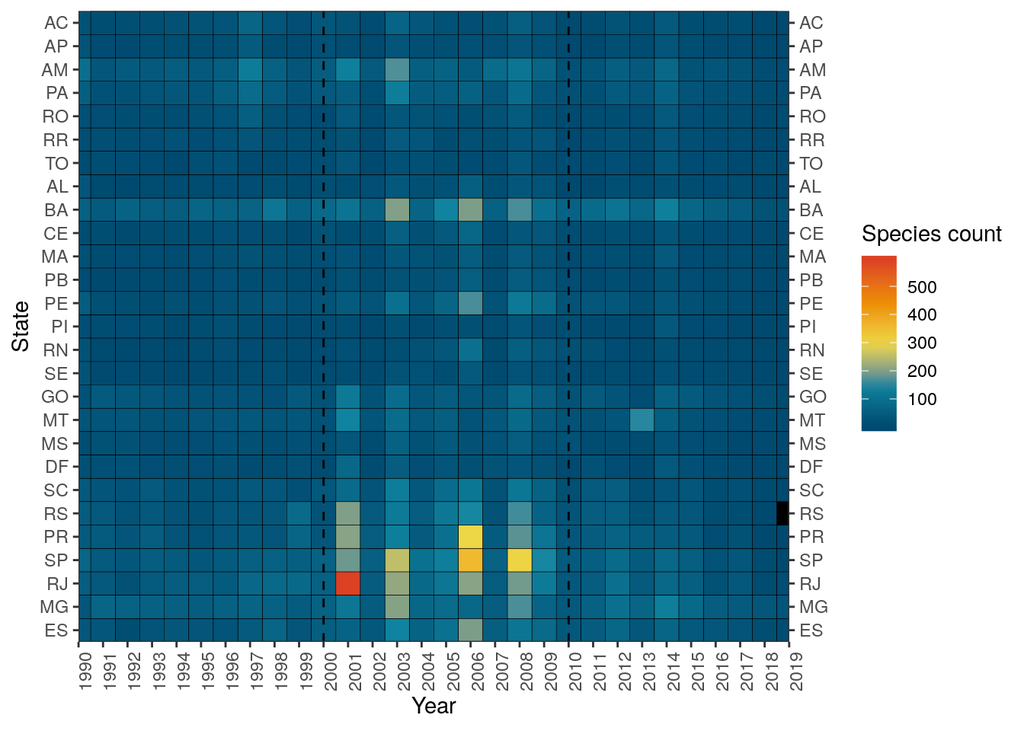

```r
x %>%
  mutate(y = fct_relevel(y,
                         "ES", "MG", "RJ","SP",
                         "PR","RS","SC",
                         "DF","MS","MT","GO",
                         "SE","RN","PI","PE","PB","MA","CE",
                         "BA","AL","TO","RR","RO","PA","AM","AP","AC")) %>%
  ggplot(aes(x, as.numeric(y), fill= value)) +
  geom_tile(colour = "black") +
  scale_fill_gradientn(colours = pal,
                       name = "Species count",
                       na.value = "black") +
  xlab("Year") + ylab("State") +
  theme_bw() +
   geom_vline(xintercept=2000, linetype = "dashed",size = 0.5) +
   geom_vline(xintercept=2010, linetype = "dashed",size = 0.5) +
  theme(axis.text.x = element_text(angle = 90),
        plot.title = element_text(hjust=0.5)) +
  coord_cartesian(xlim = c(1990,2019)) + # limited the years appearing in the plot
  scale_x_continuous(breaks = seq(1990,2019,1), expand = c(0,0)) +
  scale_y_continuous(breaks = 1:length(labs2),
                     labels = labs2,
                     sec.axis = sec_axis(~.,
                                         breaks = 1:length(labs2),
                                         labels = labs2),expand = c(0,0))
```

Além dos fatos já expostos e reforçados, é possível ver que a década entre 2000 e 2010 foi a mais prolífica até então na quantidade de espécies nativas descritas. Ainda, esse número parece cair expressivamente a partir de 2013.

Poderíamos esperar que, além da questão do financiamento, estados maiores possuem maior quantidade de espécies descritas, mas este definitivamente não é o caso, uma vez que o Rio de Janeiro, por exemplo, é um dos menores estados brasileiros. Agregando mais algumas informações isso também pode ser melhor visualizado. Além do número de espécies descritas por ano, vou combinar a extensão territorial dos estados, se eles fazem fronteiras internacionais ou não e a proporção de espécies endêmicas do total de espécies nativas descritas em cada um. Plotando todos esses dados em um único gráfico, posso tentar visualizar algumas coisas:

1. O tamanho dos estados está correlacionado com o total de espécies descritas?
2. Estados com fronteiras internacionais tem menor proporção de espécies endêmicas?
3. Quais estados tem maior número de espécies descritas e proporção de endêmicas?

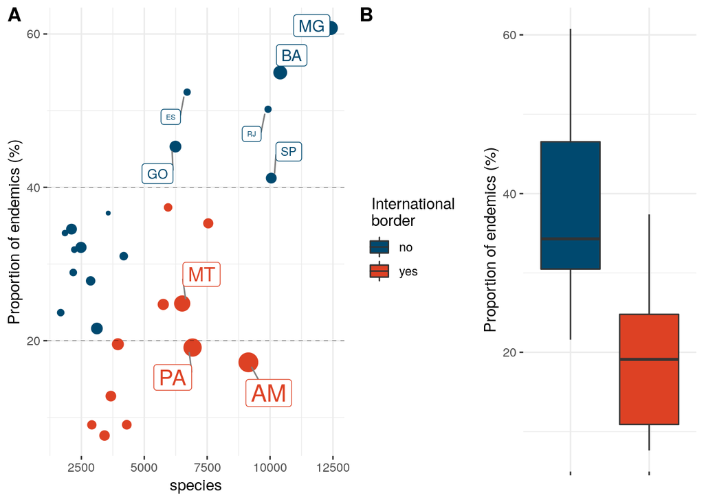

```r
####################################################
################Enxugar!!!!!!!!!!!!!################
####################################################

#vector with the initial of each state
states <- c("TO","SE","SP","SC","RR","RO","RS","RN","RJ","PI","PE","PR","PB","PA","MG","MS","MT","MA","GO","ES","DF","CE","BA","AM","AP","AL","AC")

# does the state border neighbouring countries?
border <- c("no","no","no","yes","yes","yes","yes","no","no","no","no", "yes","no","yes","no","yes","yes","no","no","no","no","no","no", "yes","yes","no","yes")

#area of each state in km2
area <- c(277720,21915,248222,95736,224300,237590,281730,52811,43780,251577,98311,199307,56585,1247954,586522,357145,903366,331937,340111,46095,5779,148920,564733,1559159,142828,27778,164123)

#combine all in a df
df_states <- tibble(state=states,area=area,border=border)

#endemics and non endemics counts per state
df_state_endemism <- df_stack_parse(df_master,column1 = "endemism",column2 = "states",parse1 = FALSE)[[1]] # note here that the column "endemism" does NOT need parsing (parse1 = FALSE)

# total number of species per state
a <- df_state_endemism %>%
      group_by(y) %>%
      summarise(species=sum(value))
# number of endemics per state
b <- df_state_endemism %>% filter(x=="Endemica") %>% group_by(y) %>% summarise(endemics=sum(value))

#join both and calculate proportions

c <- left_join(a,b,by = "y") %>% # joining the data
      mutate(prop= endemics*100/species) %>% # creating column with propotions
      rename(state=y) # renaming the state column

k <- left_join(c,df_states,by="state")

# small workaround for me to label specific points in the plot
k[['temp']] <- ""
labels <- c(13,3,11,15,5,20,27,8,9)
k[['temp']][labels] <- k$state[labels]

# first plotting the scatterplot

p1 <- k %>% filter(state != "NA") %>% ggplot(aes(x=species,y=prop,size=area,label=state,color=border)) +
  geom_point() +
  scale_color_manual(values=c(pal[1],pal[5]), name = "miau") +
  geom_hline(yintercept=20, linetype = "dashed",size = 0.1) +
  geom_hline(yintercept=40, linetype = "dashed",size = 0.1) +
  ylab("Proportion of endemics (%)") +
  theme_bw() +
  geom_label_repel(aes(label = temp),
                   box.padding   = 0.35,
                   point.padding = 0.5,
                   segment.color = 'grey50') +
  scale_size(guide = "none") +
  theme(legend.position = "none",panel.border = element_blank())


# now the boxplot

p2 <- k %>% na.omit() %>% ggplot(aes(y=prop,fill=border,x=border)) +
  geom_boxplot() +
  theme_bw() +
  scale_fill_manual(values = c(pal[1],pal[5])) +
  ylab("Proportion of endemics (%)") +
  xlab("") +
  theme(axis.text.x = element_blank(),legend.position = "left",panel.border = element_blank()) +
  labs(fill = " International \n border")

# combining both in a single grid

(p3 <- plot_grid(p1,p2, ncol = 2, labels = c("A","B")))
```

Vale notar, ainda, que os quatro estados com maiores valores de riqueza de espécies e proporção de endêmicas abrigam principalmente os domínios da Mata Atlântica e do Cerrado, dois conhecidos *hotspots* da biodiversidade, com altas taxas de diversdade em senso amplo. Estes domínios juntamente com a Caatinga, possuem as maiores proporções de endemismo do país:

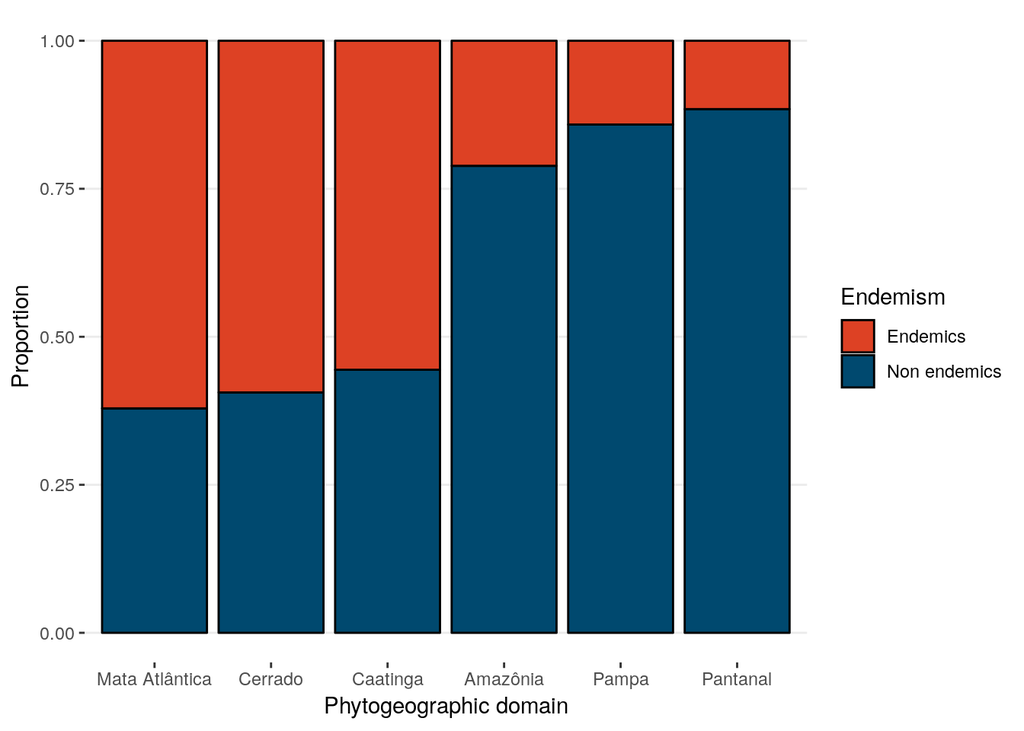

```r
df_temp <- df_stack_parse(df_master,column1 = "endemism",
                          column2 = "phytogeographic_domains",
                          parse1 = FALSE, slice_value = 3)
  df_temp[[1]] %>%
    mutate(y = fct_relevel(y,
                          "Mata Atlântica", "Cerrado", "Caatinga",
                          "Amazônia", "Pampa", "Pantanal")) %>%
  ggplot(aes(fill=x, y=value, x=y)) +
    ylab("Proportion") +
    xlab("Phytogeographic domain") +
  geom_bar(position="fill", stat="identity", color = "black") +
  theme_bw()  +
  scale_fill_manual(name = "Endemism",values=c(pal[5],pal[1]), aesthetics = "fill",labels=c("Endemics","Non endemics")) +
  removeGridX() +
  theme(panel.border = element_blank())
```

## Incluindo variáveis ecológicas ***

Mudando drasticamente a análise de direção, ainda existem mais algumas variáveis a serem checadas. Vou explorar um pouco agora os dados de formas de vida e tipos de vegetação de ocorrência das espécies. Primeiro uma olhada nas formas de vida mais frequentes da flora brasileira:

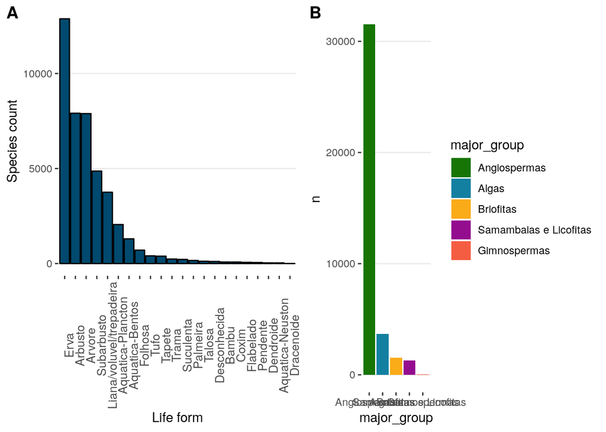

```r
df_life_forms <- as_tibble(as.data.frame(table(unlist(strsplit(as.character(df_master$life_form),split=";")))))
p1 <- df_life_forms %>%
  mutate(Var1=fct_reorder(Var1,desc(Freq))) %>%
  ggplot(aes(fill=Var1,y=Freq,x=Var1)) +
         geom_col(position = "dodge",fill=pal[1], color = "black") +
         xlab("Life form") +
         ylab("Species count") +
         theme_bw() +
         theme(axis.text.x = element_text(angle = 90,size = 10),panel.border = element_blank()) +
  removeGridX()

p2 <- df_master %>%
  count(major_group) %>% na.omit() %>% mutate(major_group=as.factor(major_group)) %>%
  mutate(major_group=fct_reorder(major_group,desc(n))) %>%
 ggplot(aes(x=major_group,y=n, fill = major_group)) + geom_bar(stat='identity', position = 'dodge') +
 scale_fill_manual(values = c('#177506', "#1380A1", "#FAAB18", '#940d8f', "#f55d42")) +
  theme_bw() +
  removeGridX() +
  theme(panel.border = element_blank())

(p3 <- plot_grid(p1,p2, ncol = 2, labels = c("A","B")))
```

Não inesperadamente, as formas de vida mais frequentes são aquelas associadas com angiospermas, seguidas de formas de vida associadas à algas e depois briófitas. Após as dez formas de vida mais frequentes (que seguem a ordem descrescente supracitada), vemos formas de vida variadas, sem ordem taxonomica. Vale ressaltar que algumas das formas de vida associadas à angiospermas são compartilhadas por Samambaias, licófitas e gimnospermas, o que influencia nesse resultado, ainda que sejam grupos com quantidade menor de espécies descritas.

Formas de vida são frequentemente associadas com os ambientes em que as espécies ocorrem. Não seria, a princípio, esperado que formas de vida ligadas a briófitas ocorressem em alta frequência em uma vegetação de clima quente e seco. Como ambos esses dados estão disponíveis, os visualizando em conjunto podem potencialmente revelar alguns padrões interessantes. Para isso vou plotar os tipos de vegetação mais frequentemete associados a cada forma de vida, no formato de um gráfico de barras empilhado:

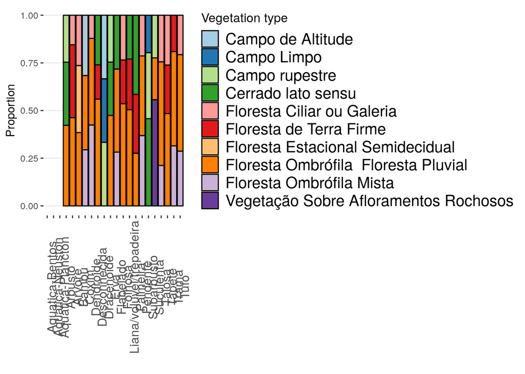

```r
#removing the suspected problematic symbols
df_master$vegetation_type <- gsub("\\(","",df_master$vegetation_type)
df_master$vegetation_type <- gsub("\\)","",df_master$vegetation_type)
df_master$vegetation_type <- gsub("=","",df_master$vegetation_type)
df_master$life_form <- as.character(df_master$life_form)

# Applying df_stack_parse to the columns and plotting
    #slicing to 3

df_temp <- df_stack_parse(df_master,column1 = "life_form",column2 = "vegetation_type",slice_value = 3)

  df_temp[[2]] %>% #select sliced df from the function output
  ggplot(aes(fill=y, y=value, x=x)) +
  ylab("Proportion") +
  xlab("") +
  geom_bar(position="fill", stat="identity", color = "black") +
    scale_fill_brewer(palette = "Paired") +
    theme_bw() +
    labs(fill='Vegetation type') +
    theme(axis.text.x = element_text(angle = 90,size = 12),
          legend.text=element_text(size=15),
          legend.title = element_text(size=12),
          panel.border = element_blank()) +
  removeGridX()
```

Nesse gráfico estão representadas os três tipos de vegetação mais frequentes para cada forma de vida e em qual proporção. Fica logo evidente a frequência com que domina a floresta ombrófila (laranja) dentre elas. Quase todas formas de vida tem essa vegetação dominando dentre as mais frequentes, o que é minimamente esperado dado que uma grande quantidade de espécies nativas ocorre em Mata Atlântica, domínio no qual este tipo de vegetação está mais associado. Outro fato interessante evidenciado por esse gráfico é a importância das vegetações sobre afloramentos rochosos para espécies suculentas: apenas nestas este tipo de vegetação figura entre as mais frequentes. É também curioso que a Floresta Ombrófila Mista esteja aparecendo nesse gráfico, dado que trata-se de um tipo de vegetação bastante devastado e restrito a regiões específicas do sul do Brasil. Ainda, todas as formas de vida que possuem essa vegetação figurando como frequente estão associadas como briófitas, algo que merece uma investigação futura.

## 2.2 Nomes vernaculares:

Por último vou analisar rapidamente alguns dados a respeito dos nomes populares disponíveis para as espécies. Quero responder duas perguntas simples:

1. Dentre as espécies com essa informação disponível, qual o nome popular mais frequente na amostra?
2. Nomes populares podem se referir a espécies de famílias botânicas diferentes?

Esses dados tem que ser limpos novamente para que a análise fique menos enviesada, dado que estes são um pouco mais sensíveis de se trabalhar. Alguns nomes aparecem capitalizados, outros não, além disso alguns símbolos não alfanuméricos podem atrapalhar a contagem. Esse é um assunto por si só, mas farei uma pequena limpeza aqui nos nomes para melhorar nos resultados e fragmentar os nomes (lembrando que cada nome vernacular de determinada espécie é separado por “;”, como no casos dos estados da federação):

```r
# removendo os hifens
df_master$vernacular_name <- tolower(gsub("-"," ",df_master$vernacular_name))

# substituindo as virgulas por pontos e virgulas
  # isso deixa todos separadores iguais
  # alguns nomes estavam separados por virgulas

df_master$vernacular_name <- tolower(gsub(",",";",df_master$vernacular_name))

# lista dos nomes mais frequentes

{table(na.omit(unlist(strsplit(df_master$vernacular_name,split=";"))))} %>% # vetor com todos nomes populares da amostra
{as_tibble(as.data.frame(.))} %>% arrange(desc(Freq)) %>% # contagem de frequencias, output como data frame
head() # seis nomes mais frequentes
```

| Var1 | Freq |
| --- | --- |
| taquara | 41 |
| envira | 36 |
| envireira | 35 |
| abiurana | 30 |
| envira preta | 29 |
| capipoatinga | 28 |

O nome popular “Taquara” é o mais frequente nessa amostra, relacionado comumente com uma variedade de [bambus](https://pt.wikipedia.org/wiki/Taquara) (família Poaceae), conhecidas por terem uso amplo, desde para a construção em geral como para a criação de instrumentos musicais. Nesse caso, todas espécies associadas com esse nome parecem pertencer à mesma família:

```r
as.character(unique(df_master$family[grep("taquara",df_master$vernacular_name,ignore.case = T)]))
```

```
## [1] "Poaceae"
```

O segundo colocado em nossa lista já não segue esse padrão:

```r
table(as.character(df_master$family[grep("envira",df_master$vernacular_name,ignore.case = T)]))
```

```
##
##    Annonaceae      Fabaceae Lecythidaceae     Malvaceae    Salicaceae
##            80             1             1             3             1
## Thymelaeaceae      Ulmaceae
##             1             2
```

Embora a esmagadora maioria das espécies com o nome “Envira” associado pertençam à familia Annonaceae, ele também parece associado a espécies de outras famílias. Embora não seja um resultado surpreendente, continua sendo um fato interessante.